# Class Activity, September 27

In this activity, you will practice fitting a regression model with a quantitative response and a single categorical predictor.

## Setup

This activity investigates the relationship between diet and wing length for the drosophila in HW 2.

Download the activity template: [activity template](https://sta112-f21.github.io/class_activities/ca_lecture_16_template.Rmd)

We can visualize the relationship between diet and wing length with boxplots:

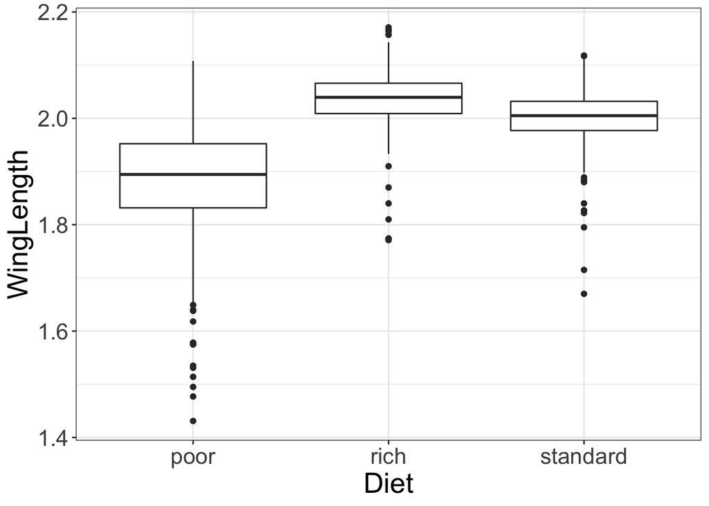

We will model this relationship as

$\text{WingLength} = \beta_0 + \beta_1 \text{IsRich} + \beta_2 \text{IsStandard} + \varepsilon$,

where $\text{IsRich}$ and $\text{IsStandard}$ are indicator variables for Diet:

There are lots of different notation for indicator variables. For example, R would call these indicators `Dietrich` and `Dietstandard`. Other notation includes $I_{\text{rich}}$ and $I_{\text{standard}}$.

$\text{IsRich} = \begin{cases} 0 & \text{Diet } \neq \text{rich} \\ 1 & \text{Diet } = \text{rich} \end{cases}$

$\text{IsStandard} = \begin{cases} 0 & \text{Diet } \neq \text{standard} \\ 1 & \text{Diet } = \text{standard} \end{cases}$

## Questions

1. Use the `lm` function to fit the regression model with Diet as the predictor and WingLength as the response.

```r
diet_lm <- lm(WingLength ~ Diet, data = drosophila)
```

2. What is the estimated average WingLength for drosophila in each diet type?

```r
summary(diet_lm)
```

```
##
## Call:
## lm(formula = WingLength ~ Diet, data = drosophila)
##
## Residuals:
##      Min       1Q   Median       3Q      Max
## -0.45005 -0.03278  0.00622  0.04058  0.22695
##
## Coefficients:
##              Estimate Std. Error t value Pr(>|t|)
## (Intercept)  1.881053   0.003364  559.18   <2e-16 ***
## Dietrich     0.155372   0.005073   30.62   <2e-16 ***
## Dietstandard 0.120727   0.004753   25.40   <2e-16 ***
## ---
## Signif. codes:  0 '***' 0.001 '**' 0.01 '*' 0.05 '.' 0.1 ' ' 1
##
## Residual standard error: 0.07462 on 1369 degrees of freedom
## Multiple R-squared:  0.4441, Adjusted R-squared:  0.4433
## F-statistic: 546.9 on 2 and 1369 DF,  p-value: < 2.2e-16
```

| Diet | $\widehat{\text{WingLength}}$ |
| --- | --- |
| Poor | 1.88 |
| Rich | 1.88 + 0.16 = 2.04 |
| Standard | 1.88 + 0.12 = 2.00 |

3. Use `dplyr` functions to calculate the sample mean WingLength for each diet in the `drosophila` data. How do your answers compare to question 2?

```r
drosophila %>%
  group_by(Diet) %>%
  summarize(mean_WingLength = mean(WingLength))
```

```
## # A tibble: 3 × 2
##   Diet     mean_WingLength
##   <chr>              <dbl>
## 1 poor                1.88
## 2 rich                2.04
## 3 standard            2.00
```

*What’s going on here?*

When we have a quantitative response and a single categorical predictor, then the predicted value of the response is just the sample mean in each group!

4. How many degrees of freedom does the fitted model from question 1 have?
5. Assess the constant variance and normality assumptions for the regression model. Do these assumptions appear reasonable?

Residual boxplot:

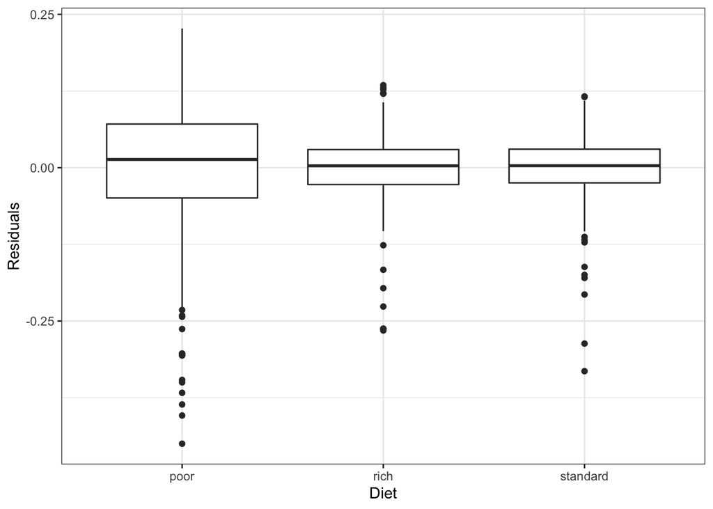

```r
drosophila %>%
  mutate(resids = residuals(diet_lm)) %>%
  ggplot(aes(x = Diet, y = resids)) +
  geom_boxplot() +
  theme_bw() +
  labs(x = "Diet",
       y = "Residuals")
```

Residual standard deviation in each group:

```r
drosophila %>%
  mutate(resids = residuals(diet_lm)) %>%
  group_by(Diet) %>%
  summarize(residual_std_dev = sd(resids))
```

```
## # A tibble: 3 × 2
##   Diet     residual_std_dev
##   <chr>               <dbl>
## 1 poor               0.104
## 2 rich               0.0525
## 3 standard           0.0495
```

QQ plot:

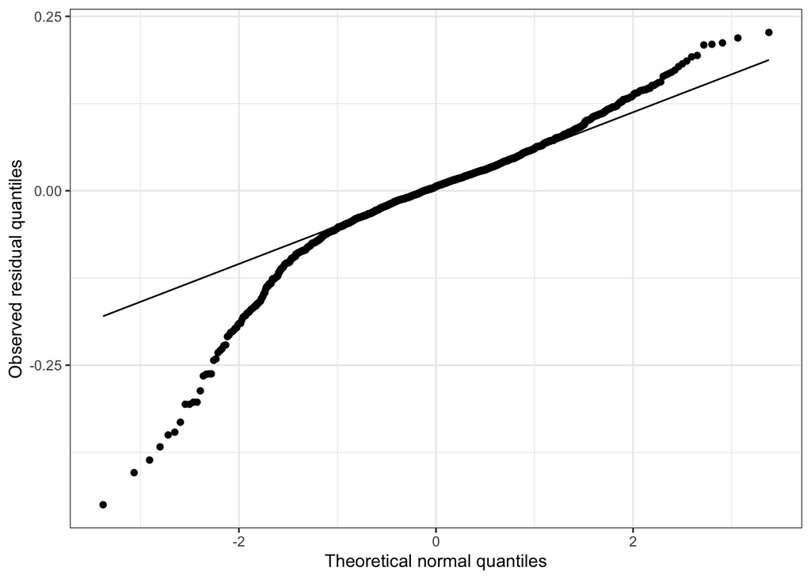

```r
drosophila %>%
  mutate(resids = residuals(diet_lm)) %>%
  ggplot(aes(sample = resids)) +
  geom_qq() +
  geom_qq_line() +
  theme_bw() +
  labs(x = "Theoretical normal quantiles",
       y = "Observed residual quantiles")
```

Both the constant variance and normality assumptions appear to be violated. For the constant variance assumption, there is noticeably more variability in residuals for the Poor diet group, and the residual standard deviation for the Poor group is more than twice the residual standard deviation for the Standard group. For the normality assumption, the QQ plot shows that the left tail is far away from the theoretical normal distribution.